# SES 5215 | Analytic Methods of Urban Planning: Quantitative

Sai Joshi, Jialei Tang, Yuanzhao Wang

2021/10/22

# Introduction

## Research Question

Does the environment sustainability status of a city impact the well-being of its citizens?

# Background

There is existing literature on the relationship between well-being and sustainability. Sustainable development, according to Helne, Tuula and Tuuli Hirvilammi in their 2015 article, has been a political catchphrase for nearly 30 years and does not represent a meaningful transition towards sustainability. Traditionally, well-being has been thought of as an economic term. Authors suggested that human well-being relies on the health of the ecosystem, and further proposed a relational, multidimensional and needs-based framework to understand well-being by having, loving, being and doing. Additionally, we found a report that examined the issue of well-being, or happiness, or quality of life, in an introspective manner. A 2020 report by De Neve and Krekel, compared the happiness of cities based solely on self-reported quality of life. They considered this approach “democratic” and “bottom-up” which “emancipates respondents to consider and weigh for themselves which factors – observable or unobservable to researchers – they feel matter most to them.” This finding, while completely subjective, aligns with other ranks that considers external factors. In this report, Scandinavian and Oceania cities score high while cities with political volatility score low. It is interesting to compare this finding to our research, or extend the survey to question if city dwellers consider sustainability as part of their well-being.

# Data

We identified the following as our variables: Categorical Variables (2)

- Vulnerability Assessment

The vulnerability assessment is a survey by the CDP, which offers a voluntary climate change reporting platform for cities. The survey asks if cities have conducted a climate change risk or vulnerability assessment for their respective local government areas in 2017.

- C40 Status

C40 is a network of mayors of nearly 100 world-leading cities collaborating to deliver the urgent action needed right now to confront the climate crisis. Whether a city has C40 status (Yes/No) depends on whether the city has met the C40 Leadership Standards as membership is by performance only. The standards are :

1. Adopted a resilience and inclusive climate action plan aligned with the 1.5 degree celsius of the Paris Agreement and updates it regularly.
2. On track to deliver its climate action plan, contributing to increased resilience, equitable outcomes and halving C40’s overall emissions by 2030.
3. Uses necessary financial, regulatory and other tools to address climate crisis and mainstrams their equitable climate targets into the most impactful city decision-making processes
4. City innovates and starts taking inclusive and resilience action beyond the direct control of the city government, such as consumption behavior in their city
5. Mayor and city demonstrate global climate leadership and inspire others to act in support of the Paris Agreement

Continuous Variables (4)

- Emissions

The emissions are taken from a CDP report in 2021, which includes records of various years from 2012-2020. It accounts for the direct and indirect emissions of metric tonnes of CO2e, including total generation of grid supplied energy within and out of the city boundaries.

- Well-being index
- Population density

Population density is the number of people who live in one square kilometer of a city, i.e. population / land area of city in square kilometers

- Percentage of Energy Use from Renewable Sources

The data set is provided by CDP. It tabulates the percentage of energy use from Coal, Oil, Nuclear, Hydro, Biomass, Geothermal, Solar and Others. The data figures range from 2013-2020 depending on the city. For our research, we calculated the percentage of energy renewable sources by summing the percentages of energy use from Nuclear, Hydro, Biomass, Geothermal, Solar and Other Sources.

# Methods

## Sample population

The cities of which data on well-being, emissions, energy mix, vulnerability assessment and could be obtained.

## Variables

### Categorical Variables (2)

- Vulnerability Assessment
- C40 Status

### Continuous Variables (4)

- Emissions
- Well-being index
- Population density
- Percentage of Energy Use from Renewable Sources

## Number of observations (rows) in our data set

Number of Observations:

291 Observations (Rows/Cities)

We intend to collate further data to include in the event that the number of cities are insufficient for analysis.

| Account.number | City | Country | Region | C40_Status | VA_Year | Climate.change.risk.or.vulnerability.assessment.done. | EMCoal | EMGas | EMOil | EMNuclear | EMHydro | EMBiomass | EMWind | EMGeothermal | EMSolar | EMOther.sources | Percentage.Renewable | EmYear | EmYearReported | City.wide.emissions.inventory | EmissionsAccountingYear | Gases.Included | Direct.emissions..metric.tonnes.CO2e..for.Total.generation.of.grid.supplied.energy | Direct.emissions..metric.tonnes.CO2e..for.Total.emissions..excluding.generation.of.grid.supplied.energy. | Indirect.emissions.from.use.of.grid.supplied.energy..metric.tonnes.CO2e..for.Total.generation.of.grid.supplied.energy | Indirect.emissions.from.use.of.grid.supplied.energy..metric.tonnes.CO2e..for.Total.Emissions..excluding.generation.of.grid.supplied.energy. | Emissions.occurring.outside.city.boundary..metric.tonnes.CO2e..for.Total.Generation.of.grid.supplied.energy | Emissions.occurring.outside.city.boundary..metric.tonnes.CO2e..for.Total.Emissions..excluding.generation.of.grid.supplied.energy. | TotalEmissions | … |
| --- | --- | --- | --- | --- | --- | --- | --- | --- | --- | --- | --- | --- | --- | --- | --- | --- | --- | --- | --- | --- | --- | --- | --- | --- | --- | --- | --- | --- | --- | --- |
| 63999 | City of Miami Beach, FL | USA | North America |  | 2017 | In progress | 3.6 | 69.8 | 0.5 | 21.7 | 0 | 0 | 0 | 0 | 0.4 | 4 | 0.26 | 2017 | 2021 | Yes | 2019-01-01 - 2019-12-31 | CH4, CO2, N20 |  | 316878.7 |  | 729150 |  | 156635 | 1202663.7 | … |
| 36223 | Antananarivo | Madagascar | Africa |  | 2017 | In progress |  |  | 80 | 0 | 20 | 0 | 0 | 0 | 0 |  | 0.2 | 2019 | 2021 | Not intending to undertake |  |  |  |  |  |  |  |  | 0 | … |
| 8242 | City of Helsinki | Finland | Europe |  | 2017 | In progress | 7.5 | 5.9 | 0.3 | 34.7 | 18.6 | 18.1 | 9.1 | 0 | 0.3 | 5.5 | 0.86 | 2019 | 2021 | Yes | 2019-01-01 - 2019-12-31 | CH4, CO2, N20 | 3233000 | 824063 |  | 1785915 |  |  | 5842978 | … |
| 35885 | Tel Aviv-Yafo Municipality | Israel | South and West Asia |  | 2017 | Yes | 25 | 70 |  |  |  |  | 0.7 |  | 4.3 |  | 0.05 | 2019 | 2021 | Yes | 2017-01-01 - 2017-12-31 | CH4, CO2, N20 |  |  |  |  |  |  | 0 | … |
| 36039 | Accra Metropolitan Assembly | Ghana | Africa | C40 | 2017 | No |  |  |  |  |  |  |  |  |  |  | 0 |  | 2021 | Yes | 2015-01-01 - 2015-12-31 | CH4, CO2, N20 |  |  |  |  |  |  | 0 | … |
| 1499 | Ajuntament de Barcelona | Spain | Europe | C40 | 2017 | In progress | 0 | 24.38 | 0.25 | 44.39 | 11.36 | 0.16 | 5.73 | 0 | 0.97 | 12.76 | 0.75 | 2018 | 2021 | Yes | 2019-01-01 - 2019-12-31 | CH4, CO2, N20 | 1121894 | 1986025 |  | 795667 |  | 60247 | 3963833 | … |

| Account.number | City | Region | X.Population | PopYear | Location | C40_Status | Vadone | Vacommenced | PercentageRenewable | PercentRenew | PopulationDensity | TotalEmissions | WellBeing |
| --- | --- | --- | --- | --- | --- | --- | --- | --- | --- | --- | --- | --- | --- |
| 63999 | City of Miami Beach, FL | USA | 91826 | 2018 | POINT (-80.13 25.7906) | No | In progress | Yes | 0.26 | 26 | 5064.86 | 1202664 | 7.028 |
| 8242 | City of Helsinki | Finland | 655395 | 2020 | POINT (24.941 60.1733) | No | In progress | Yes | 0.86 | 86 | 3059.02 | 5842978 | 7.828 |
| 35885 | Tel Aviv-Yafo Municipality | Israel | 460600 | 2019 | POINT (34.7823 32.0816) | No | Yes | Yes | 0.05 | 5 | 8857.69 | 5296900 | 7.461 |
| 36039 | Accra Metropolitan Assembly | Ghana | 2514005 | 2020 | POINT (-0.16819 5.56543) | C40 | No | No | 0.00 | 0 | 47527.32 | 2715125 | 5.267 |
| 1499 | Ajuntament de Barcelona | Spain | 1664182 | 2020 | POINT (2.1775 41.3823) | C40 | In progress | Yes | 0.75 | 75 | 16291.55 | 3963833 | 6.380 |
| 35860 | City of Dallas | USA | 1345047 | 2018 | POINT (-96.8004 32.7801) | No | No | No | 0.33 | 33 | 1349.09 | 22193276 | 7.155 |

## Reading our data

### Continuous variables:

- Emissions
- Well-being index
- Population density
- Energy Mix (Source of electricity)

[output not shown]

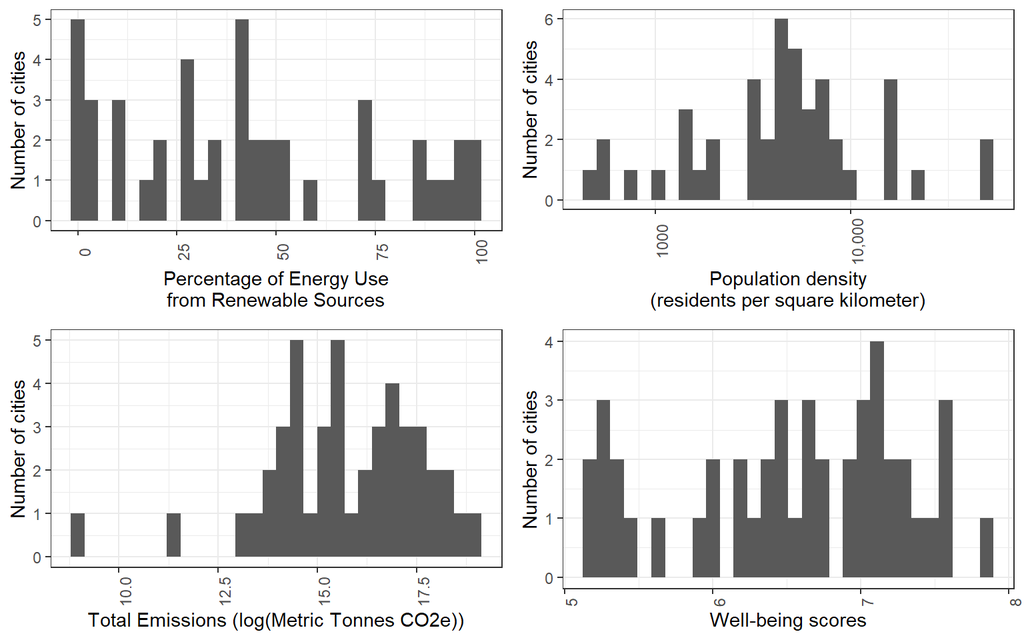

## Sample Proportion for each Category

### Categorical variables:

- Vulnerability Assessment
- C40 Status

| C40 Cities | Sample proportion | 95-percent confidence - low | 95-percent confidence - high |
| --- | --- | --- | --- |
| C40 | 71 | 57 | 85 |
| Non C40 | 29 | 15 | 43 |

### The 95-percent confidence interval for the population proportion in each category

[output not shown]

## Bivariate analysis

### Correlations / regression on continuous variables

Well-being is our key variable. The components of the well-being index are

- Annual hours of sunshine hours
- Access to green space
- Crime
- Traffic congestion
- Happiness
- Quality of healthcare
- Work-life Balance
- Governance

We recognize the limitations of this index and remain critical of its representation of the quality of life of citizens in the cities examined. Nevertheless, it is an interesting study and we are curious if the continuous and categorical variables we’ve identified can give the index more context as we establish its relationships to these variables.

In this exercise, we would like to investigate the correlations between

- well-being and emissions
- well-being and population density
- well-being and energy-mix
- population and emissions
- emissions and energy-mix

### Well-being and emissions

The p-value is more than 0.05 at 0.3891, which means the relationship is insignificant. This is also clear from the fact that the entire 95-percent confidence interval is both positive and negative, which suggests that the relationship is neither inverse or direct.

```
##
##  Pearson's product-moment correlation
##
## data:  WellBeing and TotalEmissions
## t = -0.87008, df = 43, p-value = 0.3891
## alternative hypothesis: true correlation is not equal to 0
## 95 percent confidence interval:
##  -0.4092657  0.1685066
## sample estimates:
##        cor
## -0.1315333
```

```
##
## Call:
## lm(formula = WellBeing ~ TotalEmissions, data = main)
##
## Residuals:
##     Min      1Q  Median      3Q     Max
## -1.4445 -0.4285  0.2117  0.5932  1.2328
##
## Coefficients:
##                  Estimate Std. Error t value Pr(>|t|)
## (Intercept)     6.612e+00  1.369e-01   48.30   <2e-16 ***
## TotalEmissions -2.852e-09  3.278e-09   -0.87    0.389
## ---
## Signif. codes:  0 '***' 0.001 '**' 0.01 '*' 0.05 '.' 0.1 ' ' 1
##
## Residual standard error: 0.7646 on 43 degrees of freedom
## Multiple R-squared:  0.0173, Adjusted R-squared:  -0.005552
## F-statistic: 0.757 on 1 and 43 DF,  p-value: 0.3891
```

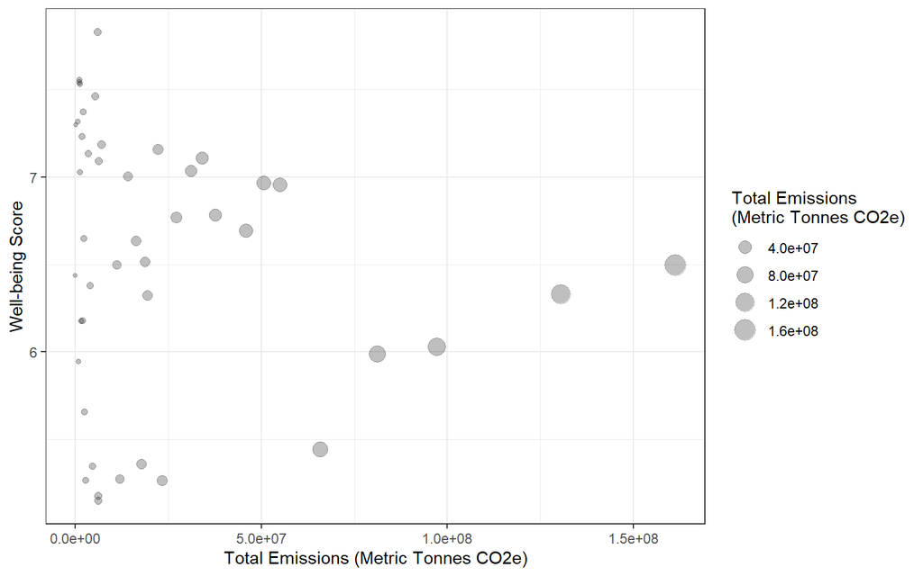

### Well-being and population density

The p-value is more than 0.05 at 0.3906, which means the relationship is insignificant. This is also clear from the fact that the entire 95-percent confidence interval is both positive and negative, which suggests that the relationship is neither inverse or direct.

```
##
##  Pearson's product-moment correlation
##
## data:  WellBeing and PopulationDensity
## t = -0.86728, df = 43, p-value = 0.3906
## alternative hypothesis: true correlation is not equal to 0
## 95 percent confidence interval:
##  -0.4089131  0.1689179
## sample estimates:
##        cor
## -0.1311172
```

```
##
## Call:
## lm(formula = WellBeing ~ PopulationDensity, data = main)
##
## Residuals:
##     Min      1Q  Median      3Q     Max
## -1.4108 -0.5151  0.1318  0.5482  1.2584
##
## Coefficients:
##                     Estimate Std. Error t value Pr(>|t|)
## (Intercept)        6.620e+00  1.423e-01  46.532   <2e-16 ***
## PopulationDensity -9.628e-06  1.110e-05  -0.867    0.391
## ---
## Signif. codes:  0 '***' 0.001 '**' 0.01 '*' 0.05 '.' 0.1 ' ' 1
##
## Residual standard error: 0.7646 on 43 degrees of freedom
## Multiple R-squared:  0.01719,    Adjusted R-squared:  -0.005664
## F-statistic: 0.7522 on 1 and 43 DF,  p-value: 0.3906
```

### Well-being and energy mix

The p-value is less than 0.05 at 0.000009851, which means the relationship is significant. This is also clear from the fact that the entire 95-percent confidence interval is positive, which suggests that the relationship is direct.

This result is interesting and it could be suggesting that cleaner cities provide better conditions for a higher well-being.

```
##
##  Pearson's product-moment correlation
##
## data:  WellBeing and PercentRenew
## t = 5.0083, df = 43, p-value = 9.851e-06
## alternative hypothesis: true correlation is not equal to 0
## 95 percent confidence interval:
##  0.3813948 0.7643308
## sample estimates:
##       cor
## 0.6069763
```

```
##
## Call:
## lm(formula = WellBeing ~ PercentRenew, data = main)
##
## Residuals:
##      Min       1Q   Median       3Q      Max
## -1.03720 -0.58602  0.08067  0.44769  1.45596
##
## Coefficients:
##              Estimate Std. Error t value Pr(>|t|)
## (Intercept)  5.932512   0.152812  38.822  < 2e-16 ***
## PercentRenew 0.014506   0.002896   5.008 9.85e-06 ***
## ---
## Signif. codes:  0 '***' 0.001 '**' 0.01 '*' 0.05 '.' 0.1 ' ' 1
##
## Residual standard error: 0.6129 on 43 degrees of freedom
## Multiple R-squared:  0.3684, Adjusted R-squared:  0.3537
## F-statistic: 25.08 on 1 and 43 DF,  p-value: 9.851e-06
```

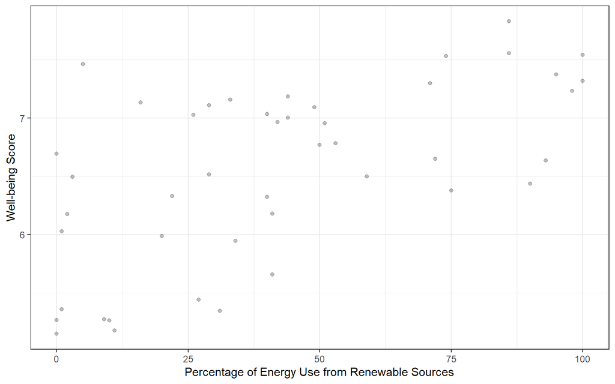

### Population density and emissions

The p-value is more than 0.05 at 0.4849, which means the relationship is insignificant. This is also clear from the fact that the entire 95-percent confidence interval is both positive and negative, which suggests that the relationship is neither inverse or direct.

```
##
##  Pearson's product-moment correlation
##
## data:  PopulationDensity and TotalEmissions
## t = -0.70459, df = 43, p-value = 0.4849
## alternative hypothesis: true correlation is not equal to 0
## 95 percent confidence interval:
##  -0.3881949  0.1927437
## sample estimates:
##        cor
## -0.1068346
```

```
##
## Call:
## lm(formula = PopulationDensity ~ TotalEmissions, data = main)
##
## Residuals:
##    Min     1Q Median     3Q    Max
##  -7894  -5198  -3271    524  44135
##
## Coefficients:
##                  Estimate Std. Error t value Pr(>|t|)
## (Intercept)     8.397e+03  1.870e+03   4.491 5.25e-05 ***
## TotalEmissions -3.155e-05  4.478e-05  -0.705    0.485
## ---
## Signif. codes:  0 '***' 0.001 '**' 0.01 '*' 0.05 '.' 0.1 ' ' 1
##
## Residual standard error: 10440 on 43 degrees of freedom
## Multiple R-squared:  0.01141,    Adjusted R-squared:  -0.01158
## F-statistic: 0.4965 on 1 and 43 DF,  p-value: 0.4849
```

### Emissions and energy mix

The p-value is less than 0.05 at 0.0105, which means the relationship is significant. This is also clear from the fact that the entire 95-percent confidence interval is negative (it does not include zero), which suggests that the relationship is inverse.

```
##
##  Pearson's product-moment correlation
##
## data:  TotalEmissions and PercentageRenewable
## t = -2.6759, df = 43, p-value = 0.0105
## alternative hypothesis: true correlation is not equal to 0
## 95 percent confidence interval:
##  -0.6043381 -0.0948096
## sample estimates:
##        cor
## -0.3778286
```

```
##
## Call:
## lm(formula = TotalEmissions ~ PercentageRenewable, data = main)
##
## Residuals:
##       Min        1Q    Median        3Q       Max
## -38330072 -21772038  -5060430   5396872 121754312
##
## Coefficients:
##                      Estimate Std. Error t value Pr(>|t|)
## (Intercept)          40732842    8209561   4.962 1.15e-05 ***
## PercentageRenewable -41638465   15560311  -2.676   0.0105 *
## ---
## Signif. codes:  0 '***' 0.001 '**' 0.01 '*' 0.05 '.' 0.1 ' ' 1
##
## Residual standard error: 32930000 on 43 degrees of freedom
## Multiple R-squared:  0.1428, Adjusted R-squared:  0.1228
## F-statistic: 7.161 on 1 and 43 DF,  p-value: 0.0105
```

## Difference in means / regression on categorical variables

### Well-being and c40 status

The p-value is more than 0.05 at 0.2037, which means the relationship is insignificant. This is also clear from the fact that the entire 95-percent confidence interval is both positive and negative, which suggests that the relationship is neither inverse or direct.

```
##
##  Welch Two Sample t-test
##
## data:  WellBeing by C40_Status
## t = -1.3131, df = 20.452, p-value = 0.2037
## alternative hypothesis: true difference in means between group C40 and group No is not equal to 0
## 95 percent confidence interval:
##  -0.8800572  0.1995235
## sample estimates:
## mean in group C40  mean in group No
##          6.447656          6.787923
```

```
##
## Call:
## lm(formula = WellBeing ~ C40_Status, data = main)
##
## Residuals:
##     Min      1Q  Median      3Q     Max
## -1.6079 -0.5007  0.1873  0.6433  1.0823
##
## Coefficients:
##              Estimate Std. Error t value Pr(>|t|)
## (Intercept)    6.4477     0.1335   48.31   <2e-16 ***
## C40_StatusNo   0.3403     0.2483    1.37    0.178
## ---
## Signif. codes:  0 '***' 0.001 '**' 0.01 '*' 0.05 '.' 0.1 ' ' 1
##
## Residual standard error: 0.755 on 43 degrees of freedom
## Multiple R-squared:  0.04184,    Adjusted R-squared:  0.01956
## F-statistic: 1.878 on 1 and 43 DF,  p-value: 0.1777
```

### Well-being and status of vulnerability assessment

```
##
##  Welch Two Sample t-test
##
## data:  WellBeing by Vacommenced
## t = -2.2926, df = 6.3158, p-value = 0.05957
## alternative hypothesis: true difference in means between group No and group Yes is not equal to 0
## 95 percent confidence interval:
##  -1.61071134  0.04273698
## sample estimates:
##  mean in group No mean in group Yes
##          5.866500          6.650487
```

```
##
## Call:
## lm(formula = WellBeing ~ Vadone, data = main)
##
## Residuals:
##     Min      1Q  Median      3Q     Max
## -1.4025 -0.5915  0.1105  0.5085  1.2885
##
## Coefficients:
##             Estimate Std. Error t value Pr(>|t|)
## (Intercept)   6.9140     0.2540  27.216  < 2e-16 ***
## VadoneNo     -1.0475     0.3881  -2.699  0.00997 **
## VadoneYes    -0.3315     0.2849  -1.163  0.25121
## ---
## Signif. codes:  0 '***' 0.001 '**' 0.01 '*' 0.05 '.' 0.1 ' ' 1
##
## Residual standard error: 0.7185 on 42 degrees of freedom
## Multiple R-squared:  0.1523, Adjusted R-squared:  0.1119
## F-statistic: 3.772 on 2 and 42 DF,  p-value: 0.03115
```

## Multivariate Regression

```
##
## Call:
## lm(formula = WellBeing ~ C40_Status + Vadone + PercentRenew +
##     PopulationDensity + TotalEmissions, data = main)
##
## Residuals:
##      Min       1Q   Median       3Q      Max
## -0.99469 -0.45165  0.03493  0.44003  1.40587
##
## Coefficients:
##                     Estimate Std. Error t value Pr(>|t|)
## (Intercept)        6.100e+00  3.173e-01  19.227  < 2e-16 ***
## C40_StatusNo       1.928e-01  2.274e-01   0.848  0.40165
## VadoneNo          -4.835e-01  3.604e-01  -1.342  0.18769
## VadoneYes         -2.819e-01  2.480e-01  -1.137  0.26269
## PercentRenew       1.450e-02  3.363e-03   4.313  0.00011 ***
## PopulationDensity -5.146e-06  9.685e-06  -0.531  0.59830
## TotalEmissions     3.238e-09  3.048e-09   1.062  0.29472
## ---
## Signif. codes:  0 '***' 0.001 '**' 0.01 '*' 0.05 '.' 0.1 ' ' 1
##
## Residual standard error: 0.6106 on 38 degrees of freedom
## Multiple R-squared:  0.4462, Adjusted R-squared:  0.3588
## F-statistic: 5.103 on 6 and 38 DF,  p-value: 0.0006287
```

The only significant relationship observed in the multivariate model is between the well-being score and the percentage of energy use from renewable sources. Apart from the well-being scores and completion of vulnerability assessment, relationships between well-being scores and other independent variables, namely C40 Status, population density and total emissions, cohere with our results from the earlier bivariate regression as insignificant.

## Transformations

### Linear Transformations

Mean Centering

In the earlier multivariate regression, the intercept predicted the well-being score for a C40 city while assuming zero values for emissions, population density, percentage of energy use from renewable sources, and a null value for vulnerability assessment status. This value is unrealistic. Through mean centering, we are able to predict a well-being score for a C40 city that assumes the average value of the other independent variables.

A city that uses less-than-average percentage energy from renewable sources would have a negative value and a city that uses more-than-average percentage energy from renewable sources would have a positive value. The same holds for population density.

The regression coefficents remain the same, but the intercept increased from 6.10 to 6.75. It refers to a C40 city average in terms of average percentage energy from renewable sources, population density, and total emissions.

The R-Value does not change and remains at 0.45 in this linear transformation.

|  | Initial | Centered |
| --- | --- | --- |
| Constant | 6.10 *** (p = 0.00) | 6.75 *** (p = 0.00) |
| Non-C40 City | 0.19 (p = 0.40) | 0.19 (p = 0.40) |
| No vulnerability assessment done | -0.48 (p = 0.19) | -0.48 (p = 0.19) |
| Conducted vulnerability assessment | -0.28 (p = 0.26) | -0.28 (p = 0.26) |
| Percentage of Energy Use from Renewable Sources % | 0.01 *** (p = 0.00) |  |
| Population Density (per sq km) | -0.00 (p = 0.60) |  |
| Total Emissions (metric tonnes CO2e) | 0.00 (p = 0.29) |  |
| Population Density (per sq km) Centered |  | -0.00 (p = 0.60) |
| Total Emissions (metric tonnes CO2e) centered |  | 0.00 (p = 0.29) |
| Percentage of Energy Use from Renewable Sources % Centered |  | 0.01 *** (p = 0.00) |
| N | 45 | 45 |
| R2 | 0.45 | 0.45 |
| *** p < 0.001; ** p < 0.01; * p < 0.05. |  |  |

### Non-Linear transformations

Logarithmic Transformation

In the preliminary examination of our dataset (see histograms in “Reading our data” section), we conducted a logarithmic transform for total emissions to visualize it in the histogram to see a better distribution. We did not use the logged values in subsequent analysis. Here, we apply a logarithmic transformation in the multivariate regression. We used a base of 2 for the log, the interpretation of that coefficient will be the effect of doubling total emissions.

|  | Initial | Centered | logged Centered |
| --- | --- | --- | --- |
| Constant | 6.10 *** (p = 0.00) | 6.75 *** (p = 0.00) | 5.65 *** (p = 0.00) |
| Non-C40 City | 0.19 (p = 0.40) | 0.19 (p = 0.40) | 0.19 (p = 0.40) |
| No vulnerability assessment done | -0.48 (p = 0.19) | -0.48 (p = 0.19) | -0.48 (p = 0.19) |
| Conducted vulnerability assessment | -0.28 (p = 0.26) | -0.28 (p = 0.26) | -0.25 (p = 0.32) |
| Percentage of Energy Use from Renewable Sources % | 0.01 *** (p = 0.00) |  |  |
| Population Density (per sq km) | -0.00 (p = 0.60) |  |  |
| Total Emissions (metric tonnes CO2e) | 0.00 (p = 0.29) |  |  |
| Population Density (per sq km) Centered |  | -0.00 (p = 0.60) | -0.00 (p = 0.56) |
| Total Emissions (metric tonnes CO2e) centered |  | 0.00 (p = 0.29) |  |
| Percentage of Energy Use from Renewable Sources % Centered |  | 0.01 *** (p = 0.00) | 0.02 *** (p = 0.00) |
| Total Emissions (metric tonnes CO2e) logged |  |  | 0.07 (p = 0.23) |
| N | 45 | 45 | 45 |
| R2 | 0.45 | 0.45 | 0.45 |
| *** p < 0.001; ** p < 0.01; * p < 0.05. |  |  |  |

The R-value remains the same as the initial and centered models. Additionally, it is rather high at 0.45. This suggests that the model was quite good to begin with. The p value for total emissions improved slightly from 0.29 to 0.23, however, this still proves that there is no significant relationship between total emissions and well-being score within a 90 or 95 percent confidence interval.

For practical purposes, we think that the mean centering model is more useful since it provides a practical prediction of a well-being score for a C40 city. On the other hand, The logarithmic transformation did not return a better model fit, and we would still not use the predicted well-being score based on total emissions as the relationship between the two is insignificant.

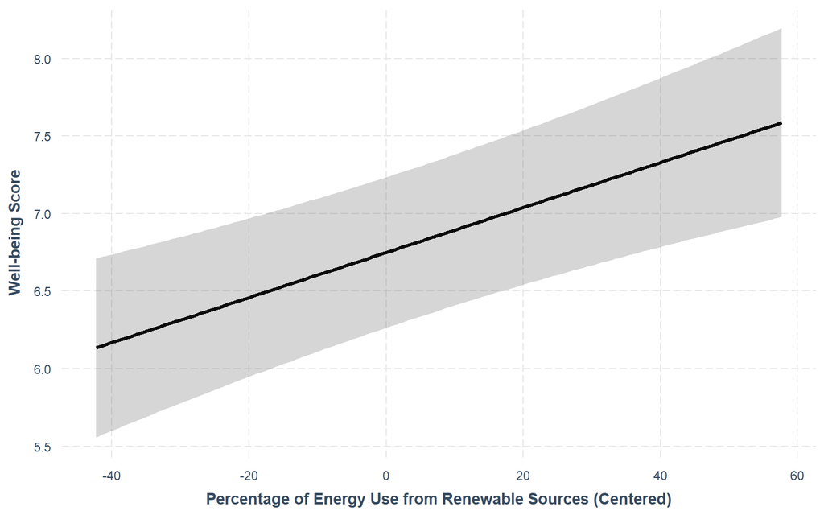

## Interaction

Based on the results above, the only significant relationship is between well-being scores and percentage of energy use from renewable sources. We are interested in whether the 1) completion of vulnerability assessment by a city and 2) C40 status will change that relationship.For this, we will use the logged centered model since we are investigating the percentage of energy from renewable sources.

|  | logged Centered | Effect of Completion of Vulnerability Assessment | Effect of C40 Status |
| --- | --- | --- | --- |
| Constant | 5.65 *** (p = 0.00) | 5.64 *** (p = 0.00) | 5.56 *** (p = 0.00) |
| Non-C40 City | 0.19 (p = 0.40) | 0.16 (p = 0.48) | 0.20 (p = 0.38) |
| No vulnerability assessment done | -0.48 (p = 0.19) | -0.13 (p = 0.82) | -0.44 (p = 0.24) |
| Conducted vulnerability assessment | -0.25 (p = 0.32) | -0.31 (p = 0.23) | -0.24 (p = 0.34) |
| Population Density (per sq km) Centered | -0.00 (p = 0.56) | -0.00 (p = 0.68) | -0.00 (p = 0.53) |
| Percentage of Energy Use from Renewable Sources % Centered | 0.02 *** (p = 0.00) | 0.01 (p = 0.38) | 0.02 ** (p = 0.00) |
| Total Emissions (metric tonnes CO2e) logged | 0.07 (p = 0.23) | 0.07 (p = 0.24) | 0.07 (p = 0.22) |
| Effect of non-completed VA |  | 0.02 (p = 0.20) |  |
| Effect of completed VA |  | 0.01 (p = 0.34) |  |
| Effect of non-C40 Status |  |  | -0.00 (p = 0.69) |
| N | 45 | 45 | 45 |
| R2 | 0.45 | 0.48 | 0.45 |
| *** p < 0.001; ** p < 0.01; * p < 0.05. |  |  |  |

While the model gives us a better fit when we interact the completion of vulnerability assessment with the percentage of energy use from renewable sources, the relationship is not strong given the high p values of 0.20 and 0.34. In other words, regardless of a city being in the progress of completing, has completed, or has not conducted vulnerability assessment, does not have a significant impact on the relationship between percentage of energy use from renewable sources and the well-being score. This insignificant (and inconsistent) relationship is shown in the graph below.

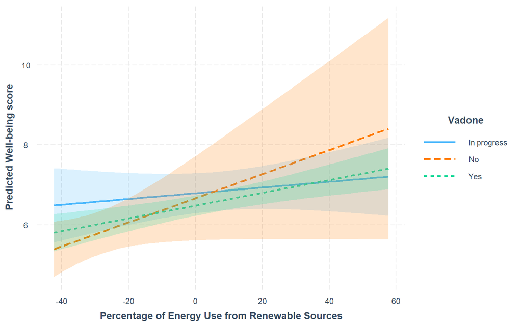

The R2 value of the C40-percentage of energy use from renewable sources interaction model does not change from the original logged Centered model remaining at 0.45. The relationship is stronger and positive at 90 percent confidence level in C40 cities than in non-C40 cities, which has a negative and very close-to-zero coefficient, and an insignificant relationship to well-being score given the high p-value of 0.69. This relationship is visualized below. Interestingly, non-C40 cities seem to have a higher predicted well-being score than C40 cities irrespective of percentage of energy use from renewable sources, converging as percentage of renewable energy use increases.

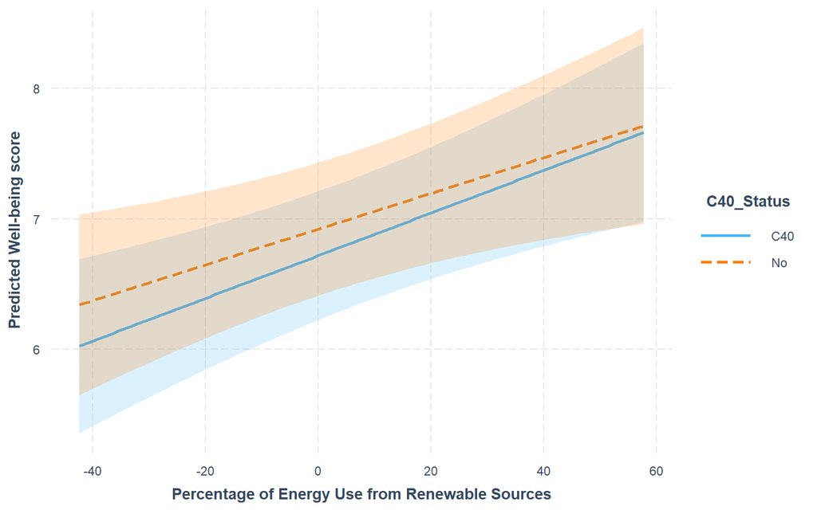

# Discussion

Our results do not fully support our hypothesis which claimed that sustainability of a city has a significant relationship to the well-being of its residents.

Limitations and Weakness

In terms of limitations and weakness, we must keep in mind that any significant relationship we found did not imply causation between these variables. We inferred that more usage of renewable energy leads to higher well-being scores, but a closer examination of the hidden relationship between the variables and the chosen indices is needed. Several transformations of data have been conducted, however, the fitness (R2 value) has remained unchanged at 0.45. The possible reason might be the lack of other control variables that can contribute to the regression model. To be more specific, the current regression model lacks some traditional control variables for well-being indices such as GDP, income, education level, and so on, which can describe people’s overall economic situation and life satisfaction that were previously considered relevant factors. For further analysis, we would include the traditional control variables for well-being indices such as GDP, income, education level in the regression model to see if the model fit improves.

Possible alternatives

In our preliminary round of research, we found 184 cities with well-being scores, 494 cities with vulnerability assessment status and emissions, and 776 cities with percentage of energy use from renewable sources. By filtering the cities with all the variables’ information, we were ultimately left with 45. We believe it would be interesting to analyze the gaps of information and the cities with those missing gaps. The model could compare the cities with well-being scores and only 1 or more sustainability-related variable’s information and examine if any significant relationships exist. For cities without well-being scores, an alternative model with other well-being ranking data, at city level or country level, could be used to investigate any significance in the relationships.

# Bibliography

“2017 - Cities Vulnerability Assessment: CDP Open Data Portal.” 2017 - Cities Vulnerability Assessment | CDP Open Data Portal, September 28, 2018.  
https://data.cdp.net/Climate-Hazards/2017-Cities-Vulnerability-Assessment/yvii-ygtz.

“2020 Cities Percentage Energy Mix: CDP Open Data Portal.” 2020 Cities Percentage Energy Mix | CDP Open Data Portal, February 26, 2021. https://data.cdp.net/Renewable-Energy/2020-Cities-Percentage-Energy-Mix/ss3g-7c4g.

“2021 City-Wide Emissions: CDP Open Data Portal.” 2021 City-wide Emissions | CDP Open Data Portal, October 4, 2021. https://data.cdp.net/Emissions/2021-City-wide-Emissions/tmta-7i7p.

“About C40.” C40 Cities, September 24, 2021. https://www.c40.org/about-c40/.

De Neve, Jan-Emmanuel, and Christian Krekel. “Cities and Happiness: A Global Ranking and Analysis.” Cities and Happiness: A Global Ranking and Analysis. Sustainable Development Solutions Network, March 20, 2020. https://worldhappiness.report/ed/2020/cities-and-happiness-a-global-ranking-and-analysis/.

Helne, Tuula, and Tuuli Hirvilammi. “Wellbeing and Sustainability: A Relational Approach.” Sustainable Development 23, no. 3 (2015): 167–75. https://doi.org/10.1002/sd.1581.

Knight Frank Research. “The Wealth Report 2021: Knight Frank.” Edited by Andrew Shirley. Global Real Estate Consultants, 2020. https://www.knightfrank.com/wealthreport.